# Machine Learning Course Project

Masswear

Oktober 2015

## Executive Summary

This project reports on the creation of an algorithm to predict the manner in which a weight-lifting exercise is performed. The model used raw sensor data from sensors attached to the body of subjects. From 52 possible predictors, 15 were selected for modeling after recursive feature elimination and correlation exclusion. A random forest model proved highly accurate with an out-of-sample error of 7.4%.

## Background

Using devices such as Jawbone Up, Nike FuelBand, and Fitbit it is now possible to collect a large amount of data about personal activity relatively inexpensively. These type of devices are part of the quantified self movement - a group of enthusiasts who take measurements about themselves regularly to improve their health, to find patterns in their behavior, or because they are tech geeks. One thing that people regularly do is quantify how much of a particular activity they do, but they rarely quantify how well they do it.

The goal of this project was to use data from sensors on the belt, forearm, arm, and dumbell of 6 participants to predict the manner in which they did a barbell lift.

This write-up describes the model-building process, its cross validation, the expected out-of-sample error, and the choices made.

## Methods

```r
Sys.info()[1:5]
```

```
##      sysname      release      version     nodename      machine
##    "Windows"      "7 x64" "build 9200"   "MASSWEAR"     "x86-64"
```

```r
R.Version()[c(1,13)]
```

```
## $platform
## [1] "x86_64-w64-mingw32"
##
## $version.string
## [1] "R version 3.1.3 (2015-03-09)"
```

Several packages were used for data processing and machine learning

```r
library(caret)
library(plyr)
library(dplyr)
library(rattle)
library(DescTools)
library(randomForest)
library(class)
library(pROC)
```

### Data

The training data for this project are available here:

https://d396qusza40orc.cloudfront.net/predmachlearn/pml-training.csv

The test data are available here:

https://d396qusza40orc.cloudfront.net/predmachlearn/pml-testing.csv

The data for this project come from this source: http://groupware.les.inf.puc-rio.br/har.

```r
##download and import the training and test data.
url_train <- "http://d396qusza40orc.cloudfront.net/predmachlearn/pml-training.csv"
url_test <- "http://d396qusza40orc.cloudfront.net/predmachlearn/pml-testing.csv"

training <- read.csv(url(url_train), sep = ",", na.strings = c("NA", "#DIV/0!", ""), stringsAsFactors = FALSE)
test <- read.csv(url(url_test), sep = ",", na.strings = c("NA", "#DIV/0!", ""), stringsAsFactors = FALSE)
```

## Results

### Exploratory Data Analysis

Data was explored to identify its structure, available variables, and possible caveats. The first 7 variables contained identifiers such as sample ID, user name, and timestamps. The next 152 variables contained the raw data and summaries calculated by the original authors. The last variable contained the classe that describes the manner in which the users performed the exercise.

Variables containing missing values were excluded from the model building process. This affected mainly the summary variables calculated by the creators of the dataset. Contrary to the original approach by Velloso et al., summary variables could not be used for prediction because the test set for evaluation did not contain any summary values. As a result, the outcome was predicted from raw data. When necessary, variable classes were adjusted to fit the desired class (e.g., factor).

```r
#transform classe and user name to factor in training set
training$classe <- as.factor(training$classe)
training$user_name <- as.factor(training$user_name)

#remove missing values
training_clean <- training[, colSums(is.na(training)) == 0]
test_clean <- test[, colSums(is.na(test)) == 0]
```

The final dataset used for modelling contained 53 variables inlcuding the outcome variable “classe”.

### Cross validation

The training set was partitioned into 2 subsets for cross validation, assigning 60% to a “cross-train” set and the remaining 40% to a “cross-test” set. To account for the time-dependence, data were split on the variable *num_window*, allowing to partition the data into time slices.

```r
set.seed(1801)
#create data frame with uniqe values of variable num_window and classe
window_classe <- training_clean %>% group_by(num_window) %>% select(60) %>% summarise_each(funs(unique))
#Sample 60% of num_window without replacement within the levels of classe
crossval <- createDataPartition(y = window_classe$classe, p = 0.60, list = FALSE)
crossval_sample <- window_classe[crossval,]
#Create cross-train set including all measurements where num_window equals the sample
cross_train <- training_clean[training_clean$num_window %in% crossval_sample$num_window,]
#create cross-test set using remaining num_windows
cross_test <- training_clean[!(training_clean$num_window %in% crossval_sample$num_window),]
```

### Feature selection

To avoid overfitting, a recursive feature elimination (rfe) process was used to select the features providing the highest accuracy. A 2-fold cross-validation with no repeats was used to improve out-of-sample accuracy.

```r
set.seed(1801)
# define the control using a random forest selection function
control <- rfeControl(functions=rfFuncs, method="cv", number=2)
# run the RFE algorithm
start_time_rfe <- Sys.time()
results <- rfe(cross_train[,8:59], cross_train[,60], sizes=c(8:59), rfeControl=control, verbose=TRUE,
               allowParallel=TRUE)
end_time_rfe <- Sys.time()
saveRDS(results, "results_rfe.Rds")
predictors(results)
```

```
##  [1] "roll_belt"            "magnet_dumbbell_z"    "yaw_belt"
##  [4] "magnet_dumbbell_y"    "pitch_forearm"        "pitch_belt"
##  [7] "accel_dumbbell_y"     "roll_dumbbell"        "magnet_dumbbell_x"
## [10] "magnet_belt_y"        "roll_arm"             "accel_dumbbell_z"
## [13] "roll_forearm"         "magnet_belt_z"        "accel_forearm_x"
## [16] "magnet_forearm_z"     "yaw_arm"              "gyros_belt_z"
## [19] "magnet_forearm_y"     "gyros_dumbbell_y"     "yaw_dumbbell"
## [22] "magnet_arm_z"         "accel_forearm_z"      "accel_belt_z"
## [25] "total_accel_dumbbell" "magnet_belt_x"        "gyros_arm_y"
## [28] "magnet_arm_x"         "accel_dumbbell_x"     "accel_forearm_y"
## [31] "gyros_arm_x"          "gyros_forearm_y"
```

The top 5 predictors were *roll_belt*, *magnet_dumbbell_z*, *yaw_belt*, *magnet_dumbbell_y*, and *pitch_forearm*.

Recursive feature elimination suggested that the best accuracy was achieved with 32 variables (accuracy of 99.2%. However, accuracy was 99.0% with only 18 features (Figure 1). Addition of more features did not increase accuracy significantly.

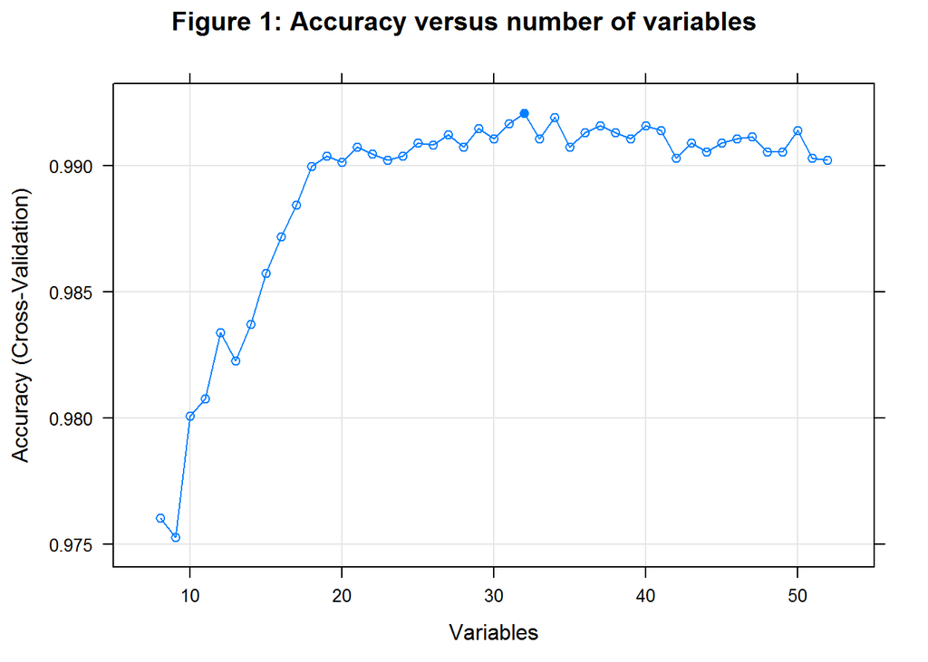

I only selected the top 18 variables to continue with modeling.

```r
rfe_predictors <- predictors(results)
cross_train_rfe <- cross_train %>% select(match(rfe_predictors[1:18],names(.)))
```

To identify redundant features, I calculated a correlation matrix of the remaining variables and excluded all variables with a correlation above 0.75 from the training set.

```r
# calculate correlation matrix
correlationMatrix <- cor(cross_train_rfe)
# set diagonal to 0
diag(correlationMatrix) <- 0
# identify variables with correlation > 0.75
which(abs(correlationMatrix)>0.75, arr.ind=TRUE)
```

```
##                   row col
## yaw_belt            3   1
## roll_belt           1   3
## magnet_dumbbell_x   9   4
## magnet_dumbbell_y   4   9
## magnet_belt_z      14  10
## magnet_belt_y      10  14
```

Apparently, *roll_belt* correlated with *yaw_belt*, *magnet_dumbbell_y* correlated with *magnet_dumbbell_x*, and *magnet_belt_z* correlated with *magnet_belt_y*. Since *roll_belt*, *magnet_dumbbell_y*, and *magnet_belt_y* showed a higher importance, I excluded *yaw_belt*, *magnet_dumbbell_x*, and *magnet_belt_z*, resulting in 15 remaining predictors.

```r
# remove highly correlated features from training set
cross_train_rfe_cor <- cross_train_rfe[-c(3, 9, 14)]
```

### Model building

The final model was built using random forests and 10-fold cross-validation on the remaining 15 features.

```r
start_time_rf <- Sys.time()
set.seed(1801)
model_rf <- train(cross_train_rfe_cor,
                  cross_train$classe,
                  method="rf",
                  trControl=trainControl(method="cv",number=10),
                  prox=TRUE,
                  verbose=TRUE,
                  allowParallel=TRUE)
end_time_rf <- Sys.time()
saveRDS(model_rf, "model_rf.Rds")
```

### out-of-sample error

To predict the out-of-sample error, I applied the random forests model to the cross-test data and calculated a confusion matrix of the predicted values versus the true values of the outcome.

```r
predictions <- predict(model_rf, newdata=cross_test)
conf_Mat <- confusionMatrix(predictions, cross_test$classe)
conf_Mat
```

```
## Confusion Matrix and Statistics
##
##           Reference
## Prediction    A    B    C    D    E
##          A 2228  126   23    0   14
##          B   10 1358  136   13   15
##          C    2   24 1046   30   29
##          D    0    2   97 1221   15
##          E    2    9    8   24 1337
##
## Overall Statistics
##
##                Accuracy : 0.9255
##                  95% CI : (0.9194, 0.9312)
##     No Information Rate : 0.2886
##     P-Value [Acc > NIR] : < 2.2e-16
##
##                   Kappa : 0.9053
##  Mcnemar's Test P-Value : NA
##
## Statistics by Class:
##
##                      Class: A Class: B Class: C Class: D Class: E
## Sensitivity            0.9938   0.8940   0.7985   0.9480   0.9482
## Specificity            0.9705   0.9722   0.9868   0.9824   0.9932
## Pos Pred Value         0.9318   0.8864   0.9248   0.9146   0.9688
## Neg Pred Value         0.9974   0.9742   0.9602   0.9896   0.9886
## Prevalence             0.2886   0.1955   0.1686   0.1658   0.1815
## Detection Rate         0.2868   0.1748   0.1346   0.1572   0.1721
## Detection Prevalence   0.3078   0.1972   0.1456   0.1718   0.1776
## Balanced Accuracy      0.9821   0.9331   0.8927   0.9652   0.9707
```

The out-of-sample accuracy of the model was 92.5%, giving an out-of-sample error of 1 - accuracy = 7.5%.

```r
missClass <-  function(values, predicted) {
  sum(predicted != values) / length(values)
}
OOS_errRate <- missClass(cross_test$classe, predictions)
OOS_errRate
```

```
## [1] 0.07452697
```

## Discussion

Using raw sensor data to predict the manner in which an exercise is performed proved highly accurate (> 90%). The feature selection process employing recursive feature elimination (rfe) followed by correlation exclusion was effective to reduce the number of features needed for accurate predictions. Hovever, rfe was very time consuming to compute. Even with a relative small 2-fold cross-validation, the process took 13 minutes to complete. A faster approach may have been the generation of a quick random forest model and arbitrary selection of the top *n* predictors. However, this approach would not allow for objective justification of *n*.

The random forests approach for modelling provided an accurate model but was rather time-consuming to generate (56 minutes). Reducing the number of folds for the cross-validation would have reduced this time.

Random forests estimate an out-of-sample error internally during creation, using bootstrapped samples. This out-of-bag (OOB) error should give an unbiased estimate of the out-of-sample error without the need of cross-validation. However, bootstrapping samples do not account for time dependence. The OOB given by the randomForest function was 0.7%, giving a 10-fold lower value comparing to our estimated error based on cross-validation accounting for time-dependence. This illustrates that the sampling process used for cross-validation is very important, especially when working with time-series data.

## Credits

This project is part of the [Practical Machine Learning Course](https://www.coursera.org/course/predmachlearn) by Jeff Leek, PhD, Roger D. Peng, PhD, Brian Caffo, PhD, offered by Johns Hopkins Bloomberg School of Public Health as part of their Data Science Specialization on Coursera.

The data used in this assignment was originally published here: [Velloso, E.; Bulling, A.; Gellersen, H.; Ugulino, W.; Fuks, H. Qualitative Activity Recognition of Weight Lifting Exercises. Proceedings of 4th International Conference in Cooperation with SIGCHI (Augmented Human ’13) . Stuttgart, Germany: ACM SIGCHI, 2013.](http://groupware.les.inf.puc-rio.br/har#wle_paper_section#ixzz3owH3ewjH)